# 14. Tutorial Model Evaluation

Tutorial ini adalah bagian dari kuliah Fundamen Sains Data, Informatika UII.

Untuk menjalankan R script di bawah ini, silakan copy dan jalankan R script pada project yang rekan-rekan buat.

Pada **Tutorial Model Evaluation** kita akan belajar beberapa hal, di antaranya:

- Data Splitting
- Cross Validation
- Confussion Matrix
- Underfitting
- Overfitting

### **Data Splitting**

Pada saat membangun model klasifikasi (*classifier*), biasanya kita akan membagi (split) dataset kita menjadi:

- Training set
- Testing set

Training set digunakan untuk membangun dan melatih *classifier*. Sedangkan testing set digunakan untuk melakukan assessment performansi model kita.

Kita juga dapat menggunakan **validation set**, yang mana validation set ini akan kita gunakan untuk memvalidasi performansi model kita sebelum digunakan untuk menguji data baru/testing set. Namun untuk lebih sederhananya, pada tutorial ini kita hanya akan membagi dataset menjadi training set dan testing set saja.

Ilustrasi contoh data splitting ini sebagai berikut:

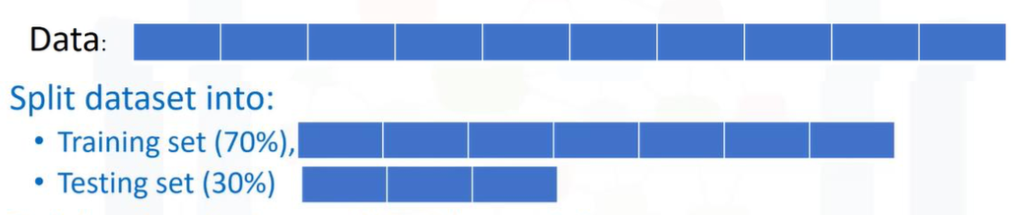

Biasanya, porsi training set akan lebih besar dari porsi testing set. Porsi ini dapat kita ubah nilainya.

Kita akan menggunakan sebuah data set (download di classroom). Letakkan file data set (hsbdemo2.txt) pada folder yang sama dengan di mana kita meletakkan R script. Load data set tersebut dengan script di bawah ini.

```r
myData <- read.csv(file="hsbdemo2.txt", header = TRUE)
myData
```

| X | id | female | ses | schtyp | prog | read | write | math | science | socst | honors | awards | cid |
| --- | --- | --- | --- | --- | --- | --- | --- | --- | --- | --- | --- | --- | --- |
| 1 | 45 | female | low | public | vocation | 34 | 35 | 41 | 29 | 26 | not enrolled | 0 | 1 |
| 2 | 108 | male | middle | public | general | 34 | 33 | 41 | 36 | 36 | not enrolled | 0 | 1 |
| 3 | 15 | male | high | public | vocation | 39 | 39 | 44 | 26 | 42 | not enrolled | 0 | 1 |
| 4 | 67 | male | low | public | vocation | 37 | 37 | 42 | 33 | 32 | not enrolled | 0 | 1 |
| 5 | 153 | male | middle | public | vocation | 39 | 31 | 40 | 39 | 51 | not enrolled | 0 | 1 |
| 6 | 51 | female | high | public | general | 42 | 36 | 42 | 31 | 39 | not enrolled | 0 | 1 |
| 7 | 164 | male | middle | public | vocation | 31 | 36 | 46 | 39 | 46 | not enrolled | 0 | 1 |
| 8 | 133 | male | middle | public | vocation | 50 | 31 | 40 | 34 | 31 | not enrolled | 0 | 1 |
| 9 | 2 | female | middle | public | vocation | 39 | 41 | 33 | 42 | 41 | not enrolled | 0 | 1 |
| 10 | 53 | male | middle | public | vocation | 34 | 37 | 46 | 39 | 31 | not enrolled | 0 | 1 |

[output cut: 190 more lines]

```r
nrow(myData)
```

```
## [1] 200
```

Pada data tersebut, banyaknya data yang kita miliki ada 200 data.

Selanjutnya, pada script di bawah ini, kita akan melakukan splitting data **myData** dengan konfigurasi sebagai berikut:

- Training set: 60%
- Testing set: 40%

```r
library(caret)
set.seed(1)

#splitting data into training and test sets
trainIndex <- createDataPartition(myData$X, p = 0.6)$Resample1

trainingSet <- myData[trainIndex, ]
testingSet <- myData[-trainIndex, ]

trainingSet
```

|  | X | id | female | ses | schtyp | prog | read | write | math | science | socst | honors | awards | cid |
| --- | --- | --- | --- | --- | --- | --- | --- | --- | --- | --- | --- | --- | --- | --- |
| 1 | 1 | 45 | female | low | public | vocation | 34 | 35 | 41 | 29 | 26 | not enrolled | 0 | 1 |
| 3 | 3 | 15 | male | high | public | vocation | 39 | 39 | 44 | 26 | 42 | not enrolled | 0 | 1 |
| 4 | 4 | 67 | male | low | public | vocation | 37 | 37 | 42 | 33 | 32 | not enrolled | 0 | 1 |
| 6 | 6 | 51 | female | high | public | general | 42 | 36 | 42 | 31 | 39 | not enrolled | 0 | 1 |
| 7 | 7 | 164 | male | middle | public | vocation | 31 | 36 | 46 | 39 | 46 | not enrolled | 0 | 1 |
| 9 | 9 | 2 | female | middle | public | vocation | 39 | 41 | 33 | 42 | 41 | not enrolled | 0 | 1 |
| 10 | 10 | 53 | male | middle | public | vocation | 34 | 37 | 46 | 39 | 31 | not enrolled | 0 | 1 |
| 12 | 12 | 128 | male | high | public | academic | 39 | 33 | 38 | 47 | 41 | not enrolled | 0 | 2 |
| 14 | 14 | 106 | female | middle | public | vocation | 36 | 44 | 37 | 42 | 41 | not enrolled | 0 | 2 |
| 15 | 15 | 89 | female | low | public | vocation | 35 | 35 | 40 | 51 | 33 | not enrolled | 0 | 2 |

[output cut: 110 more lines]

```r
testingSet
```

|  | X | id | female | ses | schtyp | prog | read | write | math | science | socst | honors | awards | cid |
| --- | --- | --- | --- | --- | --- | --- | --- | --- | --- | --- | --- | --- | --- | --- |
| 2 | 2 | 108 | male | middle | public | general | 34 | 33 | 41 | 36 | 36 | not enrolled | 0 | 1 |
| 5 | 5 | 153 | male | middle | public | vocation | 39 | 31 | 40 | 39 | 51 | not enrolled | 0 | 1 |
| 8 | 8 | 133 | male | middle | public | vocation | 50 | 31 | 40 | 34 | 31 | not enrolled | 0 | 1 |
| 11 | 11 | 1 | female | low | public | vocation | 34 | 44 | 40 | 39 | 41 | not enrolled | 0 | 1 |
| 13 | 13 | 16 | male | low | public | vocation | 47 | 31 | 44 | 36 | 36 | not enrolled | 0 | 2 |
| 16 | 16 | 134 | male | low | public | general | 44 | 44 | 39 | 34 | 46 | not enrolled | 0 | 2 |
| 17 | 17 | 19 | female | low | public | general | 28 | 46 | 43 | 44 | 51 | not enrolled | 0 | 2 |
| 19 | 19 | 11 | male | middle | public | academic | 34 | 46 | 45 | 39 | 36 | not enrolled | 0 | 2 |
| 24 | 24 | 69 | female | low | public | vocation | 44 | 44 | 40 | 40 | 31 | not enrolled | 0 | 3 |
| 28 | 28 | 155 | male | middle | public | general | 44 | 44 | 46 | 39 | 51 | not enrolled | 0 | 3 |

[output cut: 70 more lines]

Dapat dilihat bahwa sekarang dataset kita sudah terbagi menjadi dua bagian yaitu sebanyak 120 data (60%) sebagai training set dan sebanyak 80 data (40%) sebagai testing set. Kita dapat mengubah parameter *p* yang ada pada function *createDataPartition* untuk mengatur persentase banyaknya data yang akan menjadi training set.

Pada saat pembentukan model, proses sampling data (pemilihan data untuk menjadi bagian training set) yang hanya satu kali saja seringkali dapat menghasilkan *generalization performance* atau prediksi performansi model yang kurang sesuai. Oleh karena itu, untuk memperbaikinya maka dikenalkan teknik resampling menggunakan **Cross Validation**.

### **Cross Validation**

Ada beberapa jenis resampling methods yang akan kita coba di sini:

- k-fold cross validation,
- repeated k-fold cross validation, dan
- item leave-one-out-validation atau LOOV.

**Load data**. Kita akan menggunakan sebuah data set (download di classroom). Letakkan file data set (hsbdemo2.txt) pada folder yang sama dengan di mana kita meletakaan R script. Load data set tersebut dengan script di bawah ini. Amati tipe dan sebaran tiap-tiap variabel.

```r
myData <- read.csv(file="hsbdemo2.txt", header = TRUE)
summary(myData)
```

#### K-Fold Cross Validation

Pada K-Fold Cross Validation, kita akan membagi training set kita menjadi *k* fold/partisi/bagian. Salah satu partisinya akan kita gunakan sebagai validation set. Ilustrasinya sebagai berikut:

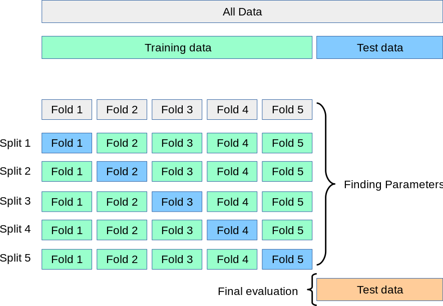

Pada ilustrasi di Gambar 2, nilai *k=5*. Fold yang berwarna biru merupakan fold yang digunakan sebagai validation set. Di setiap iterasi, bagian data yang menjadi validation set akan diganti. Setelah 5 iterasi, semua data di training set pernah menjadi data validasi.

Di bawah ini kita akan melakukan K-fold cross validation dengan *k=10*, berdasarkan data set (hsbdemo2.txt) yang dijelaskan di atas, menggunakan Naive Bayes classifier.

```r
library(caret)
train_control <- trainControl(method="cv", number=10)

modelNB <- train(prog ~ ses + female, method = "nb", trControl = train_control, data = myData)

modelNB$resample
confusionMatrix(modelNB)
```

[output not shown]

Di sini kita menggunakan paket *caret*. Secara spesifik, pada baris ke-2, kita mengatur metode resampling yang dipakai, yaitu, cross validation dengan 10 fold. Di baris ke-4, kita melakukan klasifikasi berdasarkan variabel *ses* dan *female*, ke dalam tiga kelas *prog*, menggunakan Naive Bayes classifier (“nb”). Baris ke-6 memberikan kita nilai akurasi yang diperoleh ketika setiap fold/subset data dijadikan test set. Baris ke-7 memberikan nilai rata-rata akurasi dari 10 fold.

**Confussion Matrix** Pada kode di atas, kita juga menampilkan **confussion matrix** dari hasil training menggunakan Naive Bayes classifier. Confussion matrix dapat membantu kita memahami hasil dari model yang kita buat. Contoh ilustrasi sederhana dari confussion matrix sebagai berikut:

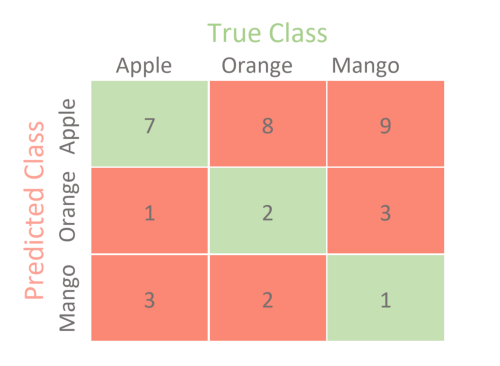

Pada Gambar 3, terdapat tiga kelas data yang akan diprediksi, yaitu: Mango, Orange, dan Apple. Confussion matrix tersebut menunjukkan bahwa:

- Dari total 24 data yang diprediksi sebagai Apple, hanya 7 data saja yang memang benar adalah Apple, 8 data lainnya seharusnya Orange, dan 9 data lainnya seharusnya Mango.
- Dari total 6 data yang diprediksi sebagai Orange, hanya 2 data saja yang memang benar adalah Orange.
- Dari total 6 data yang diprediksi sebagai Mango, hanya 1 data saja yang memang benar adalah Mango.

#### Repeated K-Fold Cross Validation

Metode ini, seperti dari namanya *repeated*, melakukan K-Fold Cross Validation berulang kali sebanyak repetisi yang kita atur. Sebagai contoh, kita melakukan 10-fold validation sebanyak 5 kali.

```r
train_control <- trainControl(method="repeatedcv", number=10, repeats=5)

modelNB <- train(prog ~ ses + female, method = "nb",
                 trControl = train_control, data = myData)

modelNB$resample
confusionMatrix(modelNB)
```

Jika kita jalankan baris ke-6, kita akan melihat akurasi dari 50 kali klasifikasi. Ini didapat dari 10 fold dikalikan 5 kali repetisi.

#### Leave-One-Out cross validation (LOOCV)

```r
train_control <- trainControl(method="LOOCV")

modelNB <- train(prog ~ ses + female, method = "nb",
                 trControl = train_control, data = myData)

modelNB$results
```

Ketika kita menggunakan LOOCV, kita tidak dapat melihat akurasi setiap fold; karena tidak ada fold.

Baris ke-6 memberikan rata-rata akurasi pada dua kondisi (*useKernel=FALSE* dan *useKernel=TRUE*). Untuk saat ini kita gunakan hasil ketika *useKernel=TRUE*.

#### Exercise

Cobalah ketiga metode di atas untuk melakukan klasifikasi pada data *iris*. Pada data ini terdapat variabel *Species* (kelas) dan variabel lainnya seperti *Sepal length*, *Sepal width*, *Petal length* dan *Petal width*. Klasifikasikan setiap spesies ke dalam kelas masing-masing, berdasarkan 4 variabel yang disebutkan di atas. Bandingkan akurasi ketika kita menggunakan 5-fold cross validation, repeated 5-fold cross validation sebanyak 10 kali, dan LOOCV.

Untuk load data set *iris*, dapat dilakukan dengan script berikut.

```r
data(iris)
dataIris <- iris
```

### **Underfitting & Overfitting**

Pada saat pemodelan, kita juga akan sering menggunakan istilah *underfitting* dan *overfitting*.

#### Underfitting

*Underfitting* merupakan kondisi di mana model kita menghasilkan akurasi yang buruk/rendah untuk data training. Sehingga dapat dikatakan bahwa model kita tidak representatif terhadap data latih yang kita miliki.

#### Overfitting

*Overfitting* merupakan kondisi di mana model kita terlalu fit terhadap data training, sehingga akurasinya sangat tinggi untuk data training. Namun, untuk data testing (data baru), akurasinya rendah.

Baik *underfitting* maupun *overfitting*, keduanya merupakan kondisi yang tidak bagus. Pada saat membuat model, baik itu model regresi maupun model klasifikasi, kita harus berusaha agar model kita tidak *underfitting* dan juga tidak *overfitting*.

Ilustrasi dari keduanya pada kasus regresi dapat kita lihat pada Gambar 4 berikut ini.

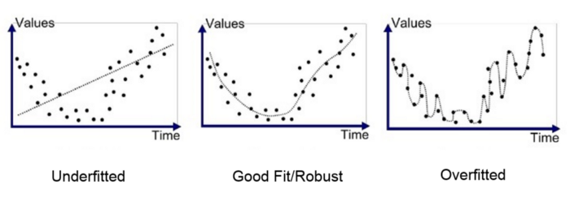

*~~ End of Tutorial ~~*